# ESS 330 Final Project

Authors

Affiliation

Sara McLaughlin

Colorado State University

Stephanie Farmer

Colorado State University

Kiara Gleiser Gherson

Colorado State University

# Freshwater Quality Analysis as an Effect of Sea Level Rise

## Abstract:

Rising sea levels, driven by climate change, are known to cause saltwater intrusion into freshwater systems, potentially compromising water quality and threatening ecosystem and human health. This study analyzes the effects of sea level rise from 2010 to 2024 in Southern Florida on increased salinity in nearby freshwater sources. We hypothesized that rising sea levels would be associated with higher salinity levels, thus degrading freshwater quality.

To test this, we compiled sea level data from NOAA’s Vaca Key gauge and salinity data from four proximal USGS freshwater gauges. Data were cleaned and filtered for the 2010–2024 period. We then employed multiple analytical methods: time series visualizations, a Prophet forecasting model, faceted scatter plots, and Spearman’s rank correlation tests.

The results of these analyses showed high interannual and inter-gauge variability in salinity, even though sea level exhibits a clear increasing trend. The forecasting model predicted relatively stable salinity levels through 2029, serving as evidence that there is no direct correlation between sea level rise and salinity. Spearman’s tests confirmed no statistically significant correlation between sea level rise and salinity levels (p > 0.05 for all gauges).

These findings suggest that local salinity dynamics in surface freshwater bodies are influenced by factors beyond sea level rise alone—such as hydrogeology, land use, and water management infrastructure. While the studied system appears resilient, the lack of correlation does not negate potential future risks. Continued monitoring and more complex, multivariable analyses are essential for anticipating climate-related threats to coastal freshwater sources as sea level will continue to rise.

## Introduction:

Sea Level rise has had significant impacts on water quality. As the sea level increases, saltwater intrusion can contaminate freshwater aquifers which reduces the availability of clean drinking water (Werner & Simmons, 2009). The intrusion of saltwater also degrades wetlands, which act as a natural water filter and are habitats for diverse aquatic species. The decrease in wetlands diminishes their ability to buffer against storm surges and filter pollutants, further compromising the water quality (Dessu et al., 2018). Rising sea levels also lead to more frequent and severe coastal flooding which can result in an overflow of sewage systems and carry pollutants into waterways. This increase in contamination can endanger public health and harm aquatic ecosystems. A previous study in an estuary in Delaware has found statistically significant increases in salinity attributed to sea level rise after adjusting measurements for flow and seasonality (Ross et al., 2015). Experimental studies have shown that the increase in salinity, both constant and fluctuating, drastically alter the nutrient dynamic in sediments in wetlands, generating important ecological implications for restoration and management of these ecosystems, which motivates analysis of how sea level rise could be affecting the water quality in coastal regions (Dijk et al., 2015). In the Perla river estuary (China), a study revealed that a sea level rise of 1 meter could extend the saline intrusion up to 18 km inland and jeopardize the access to freshwater in densely populated areas (Wang & Hong, 2021). All of these findings show the need to study similar trends in regions like Florida.

Understanding and addressing the effects of sea level rise on water quality is important for protecting freshwater resources, preserving ecosystems and ensuring the sustainability of coastal communities. Our hypothesis to address this research project is: If sea level rise has increased from 2010 to 2024 in the state of Florida, then the salinity levels in freshwater sources will also have increased, degrading overall freshwater quality. This will require two data sets: (1) sea level data from NOAA’s Tides and Current database and (2) freshwater quality (specifically, salinity) data from the USGS National Water Information System. From this data, we have constructed Spearman’s correlation tests to determine correlation, a time series to determine the strength of the relationship, a forecasted model to analyze future effects, and a scatter plot to visualize the relationship.

## Methods:

For this analysis we narrowed in on the geographic location of Southern Florida as our study system. We obtained sea level rise data from NOAA’s Tides and Currents online database (Oceanic & Administration, 2025). We obtained salinity measurement data from the U.S. Geological Survey’s downloadable discrete sample data website (Survey, 2025a). We determined which gauges to extract from the list of Florida gauges in the USGS water quality and NOAA sea level data based on closest proximity to one another. We first chose one sea level rise gauge to use (based on proximity to other USGS gauges) and then selected the four nearest USGS gauges by distance in km, according to latitude and longitudes provided in the dataset. The sea level rise gauge used was from Vaca Key, Florida, and all USGS gauges were in Southern Florida with a distance less than or equal to 73 km from the sea level gauge.

First, we cleaned the sea level rise data by removing the metadata from the downloaded file and adding a column for gauge ID. We then cleaned the salinity data by selecting only the necessary columns for analysis: columns denoting location, date of collection, descriptions of results (salinity), and result measurements (salinity in ppth). We also ensured both sea level and salinity data sets were filtered to only include dates from 2010-2024, as this is the range of years we focused on for our analysis. To begin, we first constructed a map plotting the sea level rise gauge and all four USGS salinity gauges to illustrate the locations of the gauges. This map also included surrounding bodies of water, in which the data was collected from the U.S. Geological Survey’s national map downloader (Survey, 2025b).

Once this was complete, we began the analysis. To answer our research question for this project, we conducted a time series, a forecasted model, a ggplot for easy visualization of trends, and spearman’s correlation tests. We first conducted a faceted time series in R studio highlighting trends in mean salinity over time per USGS gauge for the dates 01-01-2010 to 12-31-2024. Next, we used a prophet model to show forecasted trends in average salinity from all four gauges over the next five years (2025 - 2029). We then visualized the trends in salinity and sea level rise by employing a faceted ggplot showing both salinity at each USGS gauge and sea level rise at the singular NOAA gauge across the 14 years we analyzed. This visualization included actual points, a smoothed line curve, and a fitted trend line per gauge. Finally, we employed spearman’s correlation tests to test for significance in the relationships between sea level rise and freshwater salinity in Florida. Four spearman’s correlation tests were conducted in total, pairing each salinity gauge data to the singular sea level rise gauge data.

## Results:

Cleaning sea level rise data

```r
library(tidyverse)
library(lubridate)
library(dplyr)
library(readr)
library(purrr)
library(tsibble)
library(fable)
library(ggplot2)
library(tidyr)
library(modeltime)
library(timetk)
library(tidymodels)
library(parsnip)

f <- c("8723970_VacaKey.csv")
SLR_data <- map(f, function(i) {
  readr::read_csv(i, skip = 5, show_col_types = FALSE) |>
    dplyr::mutate(id = gsub(".csv", "", basename(i)))
}) |>
  bind_rows()
salinity_data <- read_csv("salinity.csv")
cleaned_salinity_data <- salinity_data %>%
   select(
    Location_Identifier,
    Location_Type,
    Location_State,
    Location_CountryName,
    Location_CountyName,
    Location_Latitude,
    Location_Longitude,
    Activity_Media,
    Activity_MediaSubdivision,
    Activity_StartDate,
    Result_Characteristic,
    Result_CharacteristicUserSupplied,
    Result_Measure,
    Result_MeasureUnit
  )
```

Mapped Guages

[figure not shown]

```r
library(ggplot2)
library(ggrepel)
library(readr)
library(dplyr)
library(maps)
library(sf)
locations <- read_csv("locations.csv")
states_map <- map_data("state")
florida_map <- filter(states_map, region == "florida")

data("us.cities", package = "maps")
cities_nearby <- us.cities %>%
  filter(country.etc == "FL" & pop > 170000)

nhd_dir <- "rivers"
shapefiles <- list.files(nhd_dir, pattern = "NHDFlowline.shp$", recursive = TRUE, full.names = TRUE)
nhd_list <- lapply(shapefiles, st_read, quiet = TRUE)
nhd_all <- do.call(rbind, nhd_list)

locations <- ggplot() +
  geom_sf(data = nhd_all, color = "darkblue", size = 0.03) +
  geom_polygon(data = florida_map, aes(x = long, y = lat, group = group),
               fill = "lightgrey", color = "white") +
  geom_point(data = locations, aes(x = long, y = lat), color = "red", size = 1) +
  geom_text_repel(data = locations, aes(x = long, y = lat, label = site_ID),
                  size = 3, max.overlaps = Inf, box.padding = 0.4, point.padding = 0.3) +
  geom_point(data = cities_nearby, aes(x = long, y = lat), color = "hotpink", size = 0.5) +
  geom_text_repel(data = cities_nearby, aes(x = long, y = lat, label = name),
                  size = 3, color = "hotpink", box.padding = 0.3) +
  coord_sf() +
  labs(title = "Site Locations in Florida", x = "Longitude", y = "Latitude") +
  theme_minimal()

print(locations)
```

Time Series Analysis

```r
salinity_yearly_ts <- cleaned_salinity_data %>%
  filter(Result_Characteristic == "Salinity",
         year(Activity_StartDate) >= 2010,
         year(Activity_StartDate) <= 2024) %>%
  mutate(date = as.Date(Activity_StartDate),
         year = year(date)) %>%
  group_by(Location_Identifier, year) %>%
  summarise(yearly_salinity = mean(Result_Measure, na.rm = TRUE), .groups = "drop") %>%
  mutate(year_date = as.Date(paste0(year, "-01-01"))) %>%
  as_tsibble(index = year_date, key = Location_Identifier)

timeseries <- autoplot(salinity_yearly_ts, yearly_salinity) +
  facet_wrap(~Location_Identifier, scales = "free_y") +
  labs(title = "Yearly Salinity Time Series (2010–2024)",
       y = "Mean Salinity (ppth)", x = "Year")
```

Forecasting

```r
my_date <- as.Date("2024-12-31")

combined_train_df <- salinity_yearly_ts %>%
  filter(year_date < my_date) %>%
  index_by(year_date) %>%
  summarise(yearly_salinity = mean(yearly_salinity, na.rm = TRUE)) %>%
  as_tibble()

model_prophet <- prophet_reg(seasonality_yearly = TRUE) %>%
  set_engine("prophet")
fit_prophet <- model_prophet %>% fit(yearly_salinity ~ year_date, data = combined_train_df)
```

```
Disabling weekly seasonality. Run prophet with weekly.seasonality=TRUE to override this.
```

```
Disabling daily seasonality. Run prophet with daily.seasonality=TRUE to override this.
```

```
n.changepoints greater than number of observations. Using 11
```

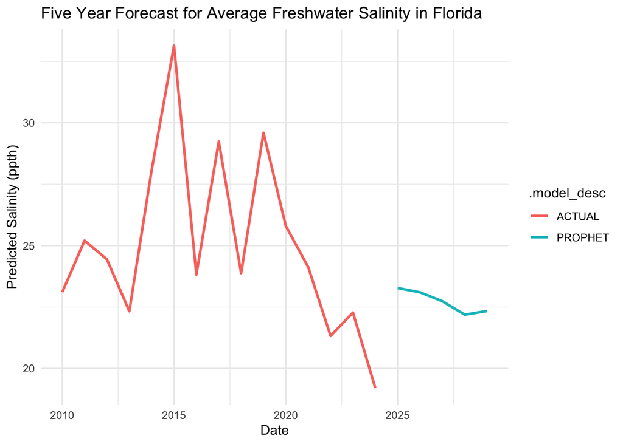

```r
future <- combined_train_df %>%
  future_frame(.date_var = year_date, .length_out = 5)

fitted_models <- modeltime_table(fit_prophet)
forecasts <- fitted_models %>%
  modeltime_forecast(new_data = future, actual_data = combined_train_df)

forecasts <- ggplot(forecasts, aes(x = .index, y = .value, color = .model_desc)) +
  geom_line(size = 1) +
  labs(title = "Five Year Forecast for Average Freshwater Salinity in Florida",
       x = "Date", y = "Predicted Salinity (ppth)") +
  theme_minimal()
print(forecasts)
```

Visualization

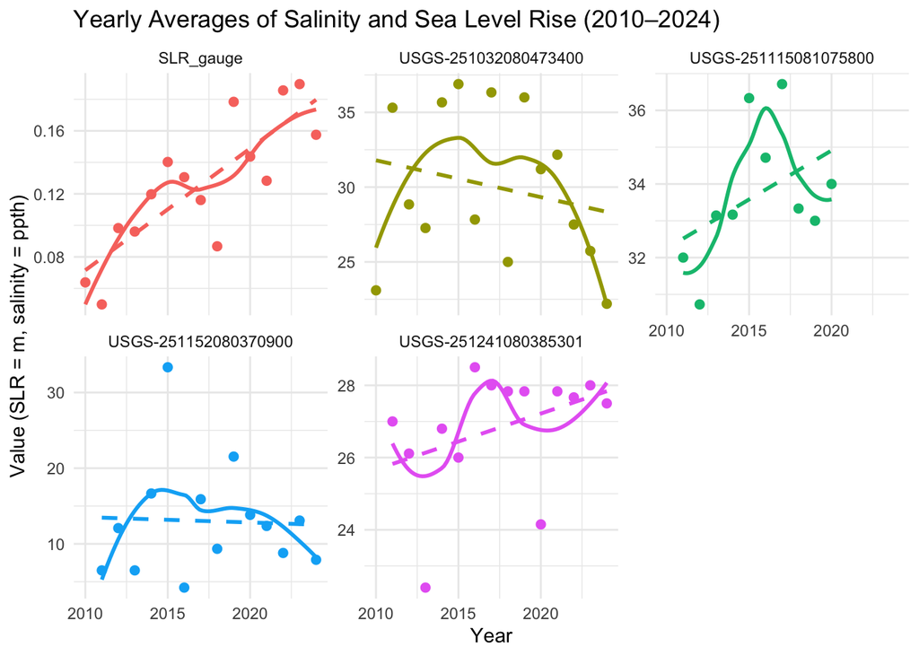

```r
salinity_yearly <- cleaned_salinity_data %>%
  filter(Result_Characteristic == "Salinity",
         year(Activity_StartDate) >= 2010,
         year(Activity_StartDate) <= 2024) %>%
  mutate(year = year(Activity_StartDate)) %>%
  group_by(Location_Identifier, year) %>%
  summarise(value = mean(Result_Measure, na.rm = TRUE), .groups = "drop") %>%
  mutate(Type = "Salinity")

slr_clean <- SLR_data %>%
  filter(Year >= 2010 & Year <= 2024) %>%
  mutate(date = as.Date(paste(Year, Month, "01", sep = "-"))) %>%
  select(date, Monthly_MSL)

slr_yearly <- slr_clean %>%
  mutate(year = year(date)) %>%
  filter(year >= 2010 & year <= 2024) %>%
  group_by(year) %>%
  summarise(value = mean(Monthly_MSL, na.rm = TRUE), .groups = "drop") %>%
  mutate(Type = "SLR",
         Location_Identifier = "SLR_gauge")

combined_yearly <- bind_rows(salinity_yearly, slr_yearly)

visuals <- ggplot(combined_yearly, aes(x = year, y = value, color = Location_Identifier)) +
  geom_point(size = 2) +  # scatter points
  geom_smooth(method = "loess", se = FALSE, size = 1, linetype = "solid") +  # smoothed curve
  geom_smooth(method = "lm", se = FALSE, size = 1, linetype = "dashed") +  # linear trend line
  facet_wrap(~Location_Identifier, scales = "free_y") +
  labs(
    title = "Yearly Averages of Salinity and Sea Level Rise (2010–2024)",
    x = "Year",
    y = "Value (SLR = m, salinity = ppth)",
    color = "Gauge"
  ) +
  theme_minimal() +
  theme(legend.position = "none")

print(visuals)
```

Spearman Correlation Test

```r
slr_clean <- SLR_data %>%
  filter(Year >= 2010 & Year <= 2024) %>%
  mutate(date = as.Date(paste(Year, Month, "01", sep = "-"))) %>%
  select(date, Monthly_MSL)

salinity_filtered <- cleaned_salinity_data %>%
  filter(Result_Characteristic == "Salinity",
         year(Activity_StartDate) >= 2010,
         year(Activity_StartDate) <= 2024) %>%
  mutate(date = as.Date(Activity_StartDate)) %>%
  group_by(Location_Identifier, year = year(date), month = month(date)) %>%
  summarise(mean_salinity = mean(Result_Measure, na.rm = TRUE), .groups = "drop") %>%
  mutate(date = as.Date(paste(year, month, "01", sep = "-")))

cor_results <- salinity_filtered %>%
  split(.$Location_Identifier) %>%
  purrr::map(~{
    merged <- inner_join(.x, slr_clean, by = "date")
    test <- cor.test(merged$mean_salinity, merged$Monthly_MSL, method = "spearman")
    tibble(
      gauge = unique(.x$Location_Identifier),
      estimate = test$estimate,
      p_value = test$p.value
    )
  }) %>%
  bind_rows()
print(cor_results)
```

```
# A tibble: 4 × 3
  gauge                estimate p_value
  <chr>                   <dbl>   <dbl>
1 USGS-251032080473400  -0.0788   0.463
2 USGS-251115081075800  -0.0896   0.558
3 USGS-251152080370900   0.0613   0.596
4 USGS-251241080385301   0.153    0.191
```

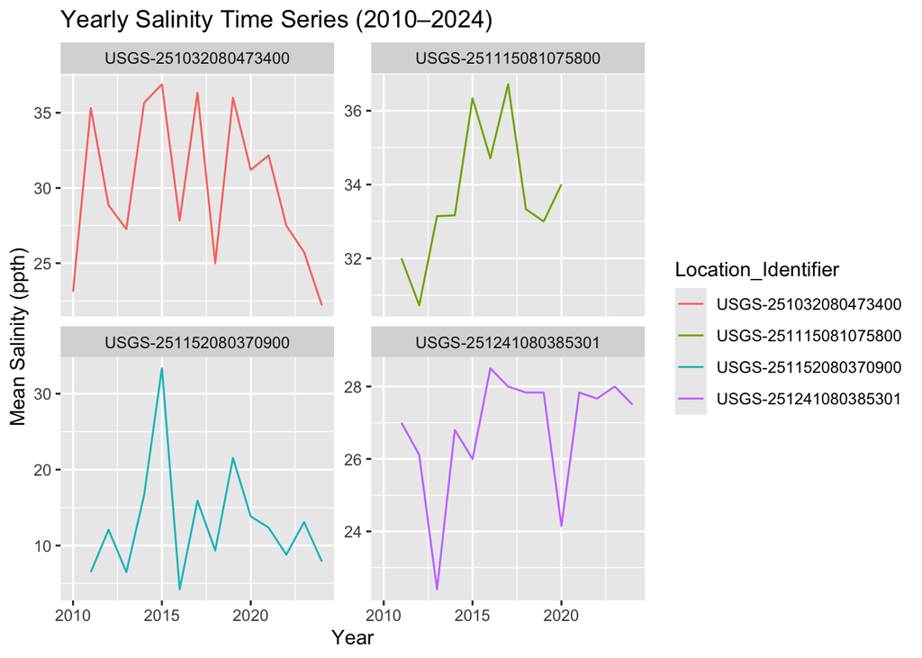

```r
print(timeseries)
```

Figure 1. Time series of yearly mean salinity in parts per thousand for each of the four USGS gauges in Florida for the years 2010-2024. Trends over time vary for each of the different gauges.

The results of our forecasting prophet model predicted relatively stable salinity levels in our region of Southern Florida for the next five years, 2025-2029. The actual salinity values of all four gauges averaged together shows variation across years 2010-2024, with a sharp decline beginning before 2020 and continuing until 2024. The model generated forecast indicates that salinity levels are predicted to be relatively stable over the next 5 year period, maintaining a salinity level around 22 ppth (Figure 2). No extremes are predicted to occur within this time frame.

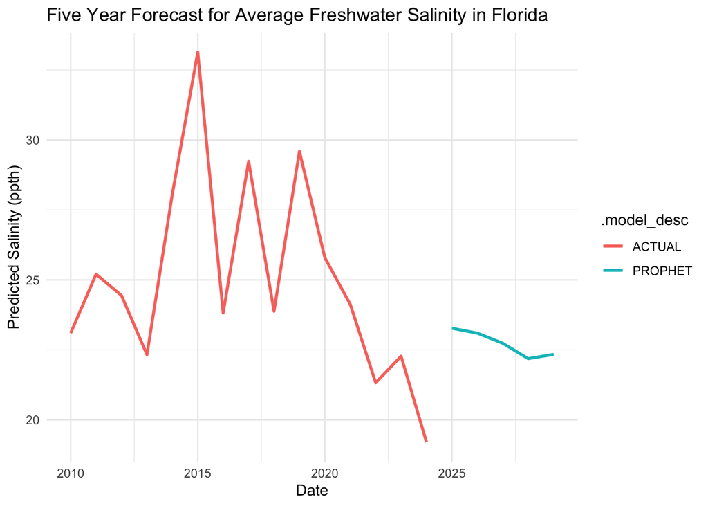

```r
print(forecasts)
```

Figure 2. Forecasted model of average salinity (ppth) from all combined USGS gauges produced with a prophet model. The red line shows actual values for years 2010-2024. The blue line shows the predicted values for years 2025-2029.

The results of the scatter plot visualization indicate that there is no clear relationship between sea level rise (SLR) trends and any of the salinity trends for the four USGS gauges. The SLR gauge displays a clear, steady upward trend over time. However, the remaining salinity gauges show varied patterns and fluctuating salinity trends (Figure 3). The included trend lines (dashed lines on the visual) allow for easy visualization of the differences in trends between salinity gauges. Two of the gauges show a trend of slightly increasing salinity, one remains extremely stable, and one shows a slight decline over time. Thus, as SLR continuously increases, salinity levels may increase, decrease, or remain relatively stable across time, varying with each gauge.

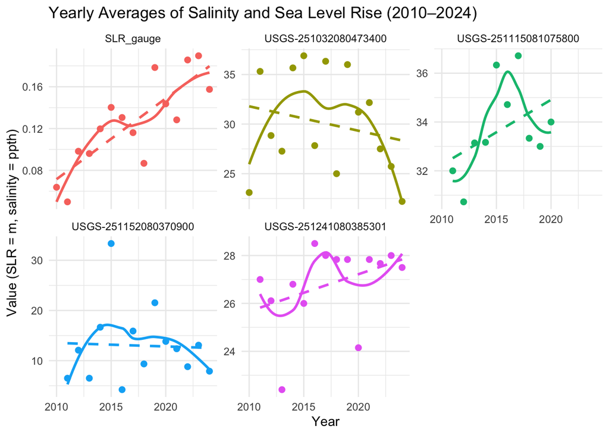

```r
print(visuals)
```

Figure 3. Faceted scatterplot shows trends in sea level rise (meters) or salinity levels (ppth) for each SLR gauge and salinity gauge. The red plot shows sea level rise while all others show salinity. Dots represent actual data points, solid lines represent smoothed lines, and the dashed lines included are trend lines for each set of data.

Finally, the results of our Spearman’s correlation tests show p-values much greater than 0.05 for every USGS salinity gauge when compared to the sea level rise data. These results suggest that there is no significant relationship between sea level rise and the selected Florida USGS water gauge salinity measurements at the 0.05 level. Thus, we fail to reject the null hypothesis that there is no correlation between sea level rise and freshwater salinity in Florida.

# 7. Discussion:

The findings show that, even though sea levels have increased in a constant manner, this increase does not translate into a corresponding increase in salinity levels of freshwater in the sites analyzed in this study. This disconnect could be explained by factors such as local hydrogeology, precipitation patterns, groundwater management and land use changes which are also known to influence freshwater quality.

Another study showed that although there was a clear retreat of the interface between fresh and salt water linked to sea level rise documented in coastal aquifers (Werner & Simmons, 2009), our results do not show a significant relationship in surface water bodies, suggesting a substantial difference in the hydrological response mechanisms between subsystems. Contrary to this, a study conducted in the estuary of the St. Marks River in Florida actually projected increases in salinity as high as 12.7 ppth under sea level rise scenarios (Xiao et al., 2014), and what was observed in Chesapeake Bay was that sea level rise explained a significant upward trend in residual salinity (Hilton et al., 2008). These differ from our study in the south of Florida that did not identify any correlation between the variables, which could be due to localized hydrological characteristics. Additionally, the presence of flood control infrastructure and water treatment plants could be buffering or altering the direct effect of the sea levels over the freshwater sources.

Even though the time series model shows varied patterns, the prophet forecast model suggests that in the near future, the salinity levels won’t experience drastic changes. This could reveal a temporary resilience of the water system in the studied locations. Nevertheless, the complexity of environmental processes in coastal zones requires more integrated models.

There are multiple limitations to this study, including the use of a single gauge per zone, the lack of additional climate variables, and the need to extend the temporal and spatial resolution of the study. For future studies, a multivariable focus and a long term analysis would enhance the study of freshwater quality in terms of sea level rise.

In conclusion, we fail to reject the null hypothesis that the increase in sea levels is not correlated to changes in freshwater salinity levels. Even though the data analyzed do not show a direct correlation between sea level increase and freshwater salinity in Florida, it highlights the urgent need to have continued monitoring. These kinds of studies are key to anticipate the possible cumulative effects of climate change and to help make informed decisions in the management of water resources in vulnerable regions. Combined with rising sea levels and saltwater intrusion, estuarine systems face multiple other stressors that require an integrated response, with policy, technological, and ecological solutions required to face them.

## References

Dessu, S. B., Price, R. M., Troxler, T. G., & Kominoski, J. S. (2018). Effects of sea-level rise and freshwater management on long-term water levels and water quality in the florida coastal everglades. *Journal of Environmental Management*, *211*, 164–176.

Dijk, G. van, Smolders, A. J., Loeb, R., Bout, A., Roelofs, J. G., & Lamers, L. P. (2015). Salinization of coastal freshwater wetlands; effects of constant versus fluctuating salinity on sediment biogeochemistry. *Biogeochemistry*, *126*, 71–84.

Hilton, T., Najjar, R., Zhong, L., & Li, M. (2008). Is there a signal of sea-level rise in chesapeake bay salinity? *Journal of Geophysical Research: Oceans*, *113*(C9).

Oceanic, N., & Administration, A. (2025). *Sea level trends - NOAA tides and currents*. https://tidesandcurrents.noaa.gov/sltrends/sltrends_station.shtml?id=8723970

Ross, A. C., Najjar, R. G., Li, M., Mann, M. E., Ford, S. E., & Katz, B. (2015). Sea-level rise and other influences on decadal-scale salinity variability in a coastal plain estuary. *Estuarine, Coastal and Shelf Science*, *157*, 79–92.

Survey, U. S. G. (2025a). *Discrete sample data - USGS water data for the nation*. https://waterdata.usgs.gov/download-samples/#sampleMedia=Water&observedProperty=Salinity%2C%20water&statecode=US:12&startDate=2010-01-01&endDate=2024-12-31&dataProfile=fullphyschem

Survey, U. S. G. (2025b). *National map downloader*. https://apps.nationalmap.gov/downloader/#/

Wang, J., & Hong, B. (2021). Threat posed by future sea-level rise to freshwater resources in the upper pearl river estuary. *Journal of Marine Science and Engineering*, *9*(3), 291.

Werner, A., & Simmons, C. (2009). Impact of sea-level rise on sea water intrusion in coastal aquifers. *Ground Water*, *47*, 197–204. https://doi.org/10.1111/j.1745-6584.2008.00535.x

Xiao, H., Huang, W., Johnson, E., Lou, S., & Wan, W. (2014). Effects of sea level rise on salinity intrusion in st. Marks river estuary, florida, USA. *Journal of Coastal Research*, *68*, 89–96.